# Data Wrangling Practice With Chicago Air Pollution Data

Yurong Fan

## 1. Load the dataset `chicago.rds`

```r
chicago = readRDS("chicago.rds")
```

## 2. Data Cleaning

Import related libraries and convert dataset to tbl dataframe before start.

### Clearning missing values

I first summarized the number of missing data for each attributes. The result below shows pm25tmean2 contains 4447 cases of missing data which makes 64% of its total records. the other attributes contains missing data which makes equal or less than 3% of total records.

**So for the sake of simplicity, I assume the attributes containing less than 3% missing data are missing completely at random and omit rows with their missing data for later analysis.**

**Total numbers of missing values**

```r
sapply(chicago, function(x) sum(is.na(x)))
```

```
##       city       tmpd       dptp       date pm25tmean2 pm10tmean2
##          0          1          2          0       4447        242
##   o3tmean2  no2tmean2
##          0          0
```

**Proportion of total rows of missing values**

```r
sapply(chicago, function(x) round(sum(is.na(x))/nrow(chicago),2))
```

```
##       city       tmpd       dptp       date pm25tmean2 pm10tmean2
##       0.00       0.00       0.00       0.00       0.64       0.03
##   o3tmean2  no2tmean2
##       0.00       0.00
```

For PM2.5, I made a plot to further identify the pattern of its missing values. The plot shows that there is no value of PM2.5 for years before 1998, and larege amounts of PM2.5 data missing in year 1998 and 1999. Since year 2000, PM2.5 seems to contain little missing data.

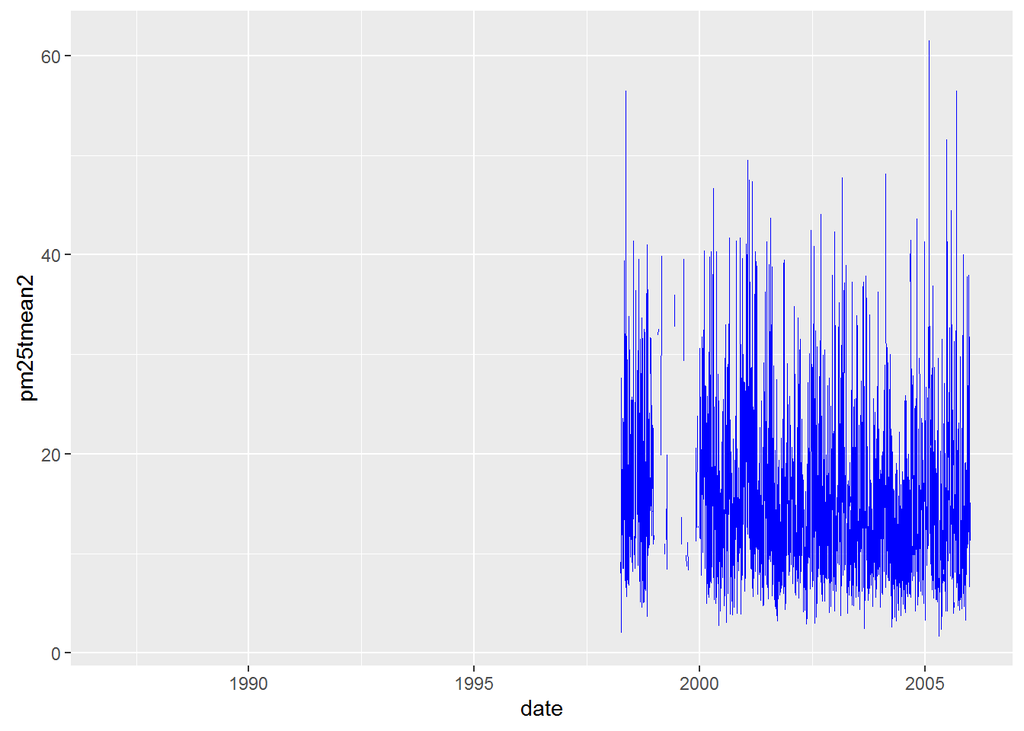

```r
ggplot(chicago,aes(x=date, y=pm25tmean2)) + geom_line(size = 0.01, color = "blue")
```

I further summarized the proportion of missing values to confirm my observations. In years since 2000, there are only 3% missing values in PM2.5.However year 1998 and 1999 contain 29% and 72% respectively of PM2.5 missing data. Including PM2.5 data before year 2000 is highly possbile to introduce bias when making PM2.5 by year analysis. **To keep consistency, I only used data since year 2000 for any analysis related to PM2.5 and assmued its 3% PM2.5 missing values are missing completely at random thus omitting rows with them for the sake of simplicity**.

**Proportion of total rows containing missing data for the subset of data since year 2000**

```r
filter(chicago, date >= as.Date("2000-01-01")) %>%
sapply(function(x)round(sum(is.na(x))/nrow(filter(chicago, date >= as.Date("2000-01-01"))),2))
```

```
##       city       tmpd       dptp       date pm25tmean2 pm10tmean2
##       0.00       0.00       0.00       0.00       0.03       0.00
##   o3tmean2  no2tmean2
##       0.00       0.00
```

**Proportion of total rows containing missing data for the data in year 1998**

```r
filter(chicago, date >= as.Date("1998-01-01") & date < as.Date("1999-01-01")) %>%
sapply(function(x)round(sum(is.na(x))/nrow(filter(chicago, date >= as.Date("1998-01-01") & date < as.Date("1999-01-01"))),2))
```

```
##       city       tmpd       dptp       date pm25tmean2 pm10tmean2
##       0.00       0.00       0.00       0.00       0.29       0.00
##   o3tmean2  no2tmean2
##       0.00       0.00
```

**Proportion of total rows containing missing data for the data in year 1999**

```r
filter(chicago, date >= as.Date("1999-01-01") & date < as.Date("2000-01-01")) %>%
sapply(function(x)round(sum(is.na(x))/nrow(filter(chicago, date >= as.Date("1999-01-01") & date < as.Date("2000-01-01"))),2))
```

```
##       city       tmpd       dptp       date pm25tmean2 pm10tmean2
##       0.00       0.00       0.00       0.00       0.72       0.00
##   o3tmean2  no2tmean2
##       0.00       0.00
```

### cleaning outliers

I plotted the boxplot to identify outliers of each factor and also used density plot to exclude “outliers” that are probably tail data from skewed distributions.

> TMPD Outlier Cleaning

For tmpd, the only plot below whisker is not far away and is probably data from the left tail of the left skewed tmpd sample distribution.**I will assume the population of tmpd also follows left skewed distribution thus will not recognize it as outlier.**

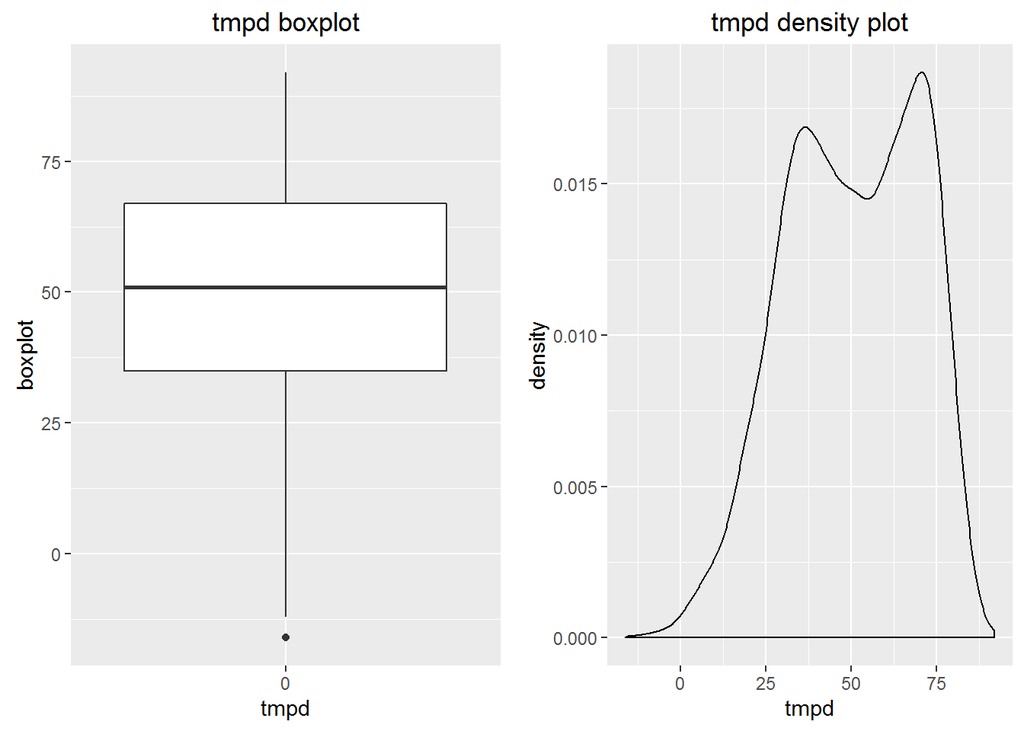

```r
g1 <- ggplot(chicago,aes(x=factor(0), y=tmpd)) + geom_boxplot() + labs(title = "tmpd boxplot", x = "tmpd", y = "boxplot")
g2 <- ggplot(chicago,aes(tmpd)) + geom_density() + labs(title = "tmpd density plot", x = "tmpd", y = "density")
grid.arrange(g1,g2,ncol = 2)
```

> DPTP Outlier Cleaning

For dptp, the points below whisker in the box plot are probably data from the left tail of the left skewed dptp sample distribution.**I will assume the population of dptp also follows left skewed distribution thus will not recognize them as outliers.**

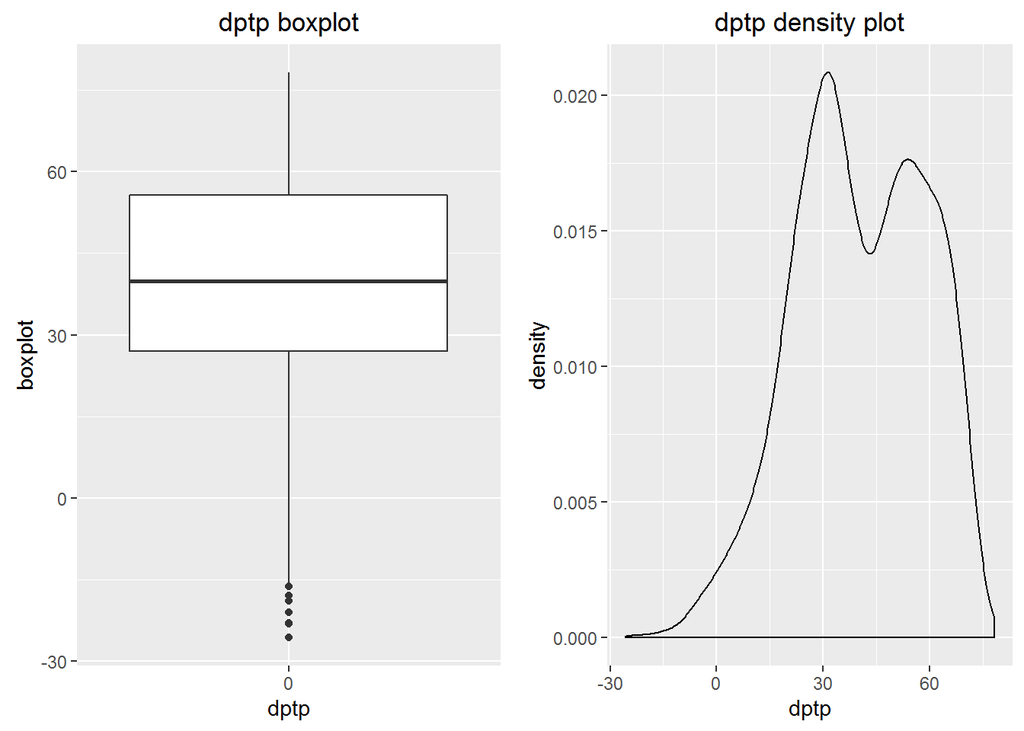

```r
g3 <- ggplot(chicago,aes(x=factor(0), y=dptp)) + geom_boxplot() + labs(title = "dptp boxplot", x = "dptp", y = "boxplot")
g4 <- ggplot(chicago,aes(dptp)) + geom_density() + labs(title = "dptp density plot", x = "dptp", y = "density")
grid.arrange(g3,g4,ncol = 2)
```

> PM2.5 Outlier Cleaning

For PM2.5, the points above whisker in the box plot are probably data from the right tail of the right skewed PM2.5 sample distribution.**I will assume the population of PM2.5 also follows right skewed distribution thus will not recognize them as outliers.**

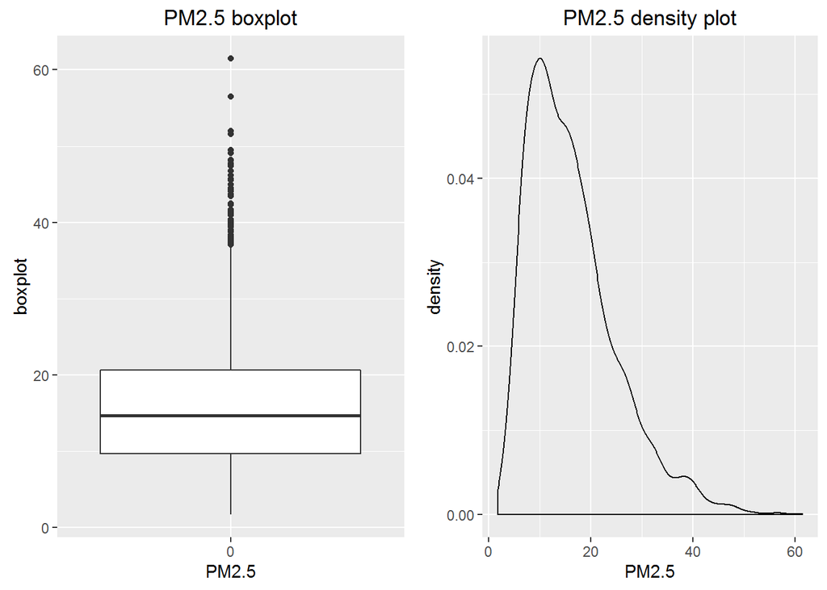

```r
g5 <- ggplot(chicago,aes(x=factor(0), y=pm25tmean2)) + geom_boxplot() + labs(title = "PM2.5 boxplot", x = "PM2.5", y = "boxplot")
g6 <- ggplot(chicago,aes(pm25tmean2)) + geom_density() + labs(title = "PM2.5 density plot", x = "PM2.5", y = "density")
grid.arrange(g5,g6,ncol = 2)
```

> PM10 Outlier Cleaning

**For PM10, the highest two points are far away from the others in the box plot, I will recognize them as an outliner and replace with NA.** Other points above whisker are probably data from the right tail of the right skewed PM10 sample distribution.**I will assume the population of PM10 is also right skewed thus will not recognize them as outliers.**

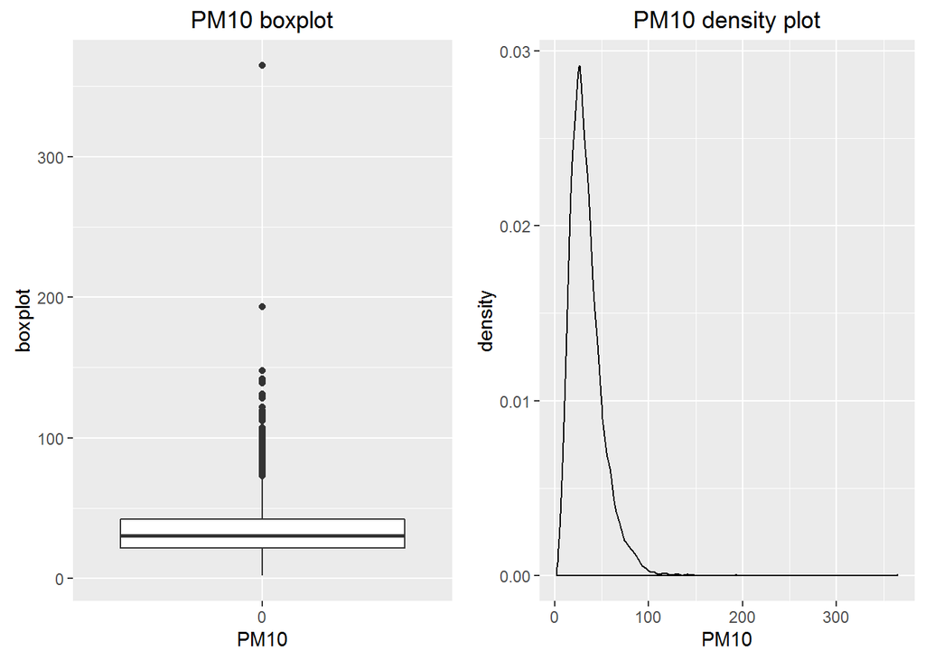

```r
g7 <- ggplot(chicago,aes(x=factor(0), y=pm10tmean2)) + geom_boxplot() + labs(title = "PM10 boxplot", x = "PM10", y = "boxplot")
g8 <- ggplot(chicago,aes(pm10tmean2)) + geom_density() + labs(title = "PM10 density plot", x = "PM10", y = "density")
grid.arrange(g7,g8,ncol = 2)
```

> Ozone (O3) Outlier Cleaning

For O3, the points above whisker in the box plot are probably data from the right tail of the right skewed O3 sample distribution.**I will assume the population of O3 also follows right skewed distribution thus will not recognize them as outliers.**

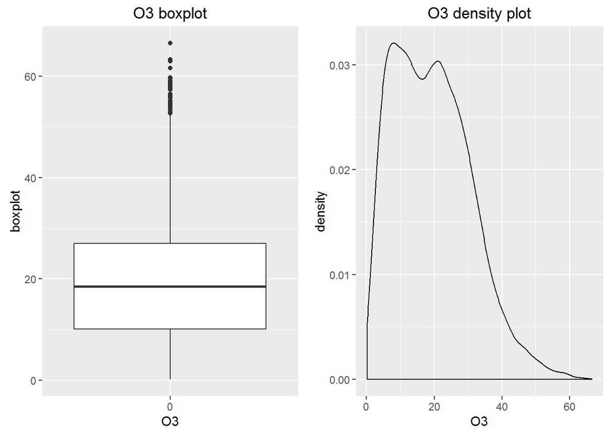

```r
g9 <- ggplot(chicago,aes(x=factor(0), y=o3tmean2)) + geom_boxplot() + labs(title = "O3 boxplot", x = "O3", y = "boxplot")
g10 <- ggplot(chicago,aes(o3tmean2)) + geom_density() + labs(title = "O3 density plot", x = "O3", y = "density")
grid.arrange(g9,g10,ncol = 2)
```

> NO2 Outlier Cleaning

For NO2, the points above whisker in the box plot are probably data from the right tail of the right skewed NO2 sample distribution.**I will assume the population of NO2 also follows right skewed distribution thus will not recognize them as outliers.**

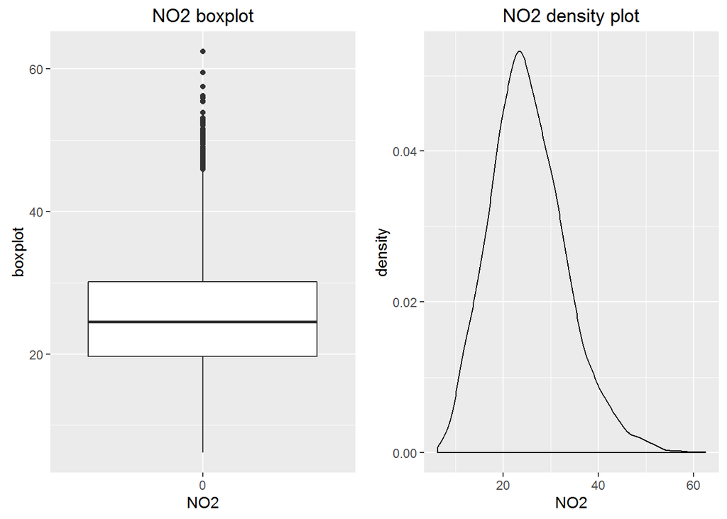

```r
g11 <- ggplot(chicago,aes(x=factor(0), y=no2tmean2)) + geom_boxplot() + labs(title = "NO2 boxplot", x = "NO2", y = "boxplot")
g12 <- ggplot(chicago,aes(no2tmean2)) + geom_density() + labs(title = "NO2 density plot", x = "NO2", y = "density")
grid.arrange(g11,g12,ncol = 2)
```

> Replace Outliers with NA

Replace detected two outliers in PM10 with NA.

Name subset of data of year 2000 and after as “chicago_since2000” for analysis related with PM2.5.

## 3. Extracting rows with high PM2.5

Below is the density plot of PM2.5 values in years from 2000 to 2005 with quantile lines over it. The distribution of PM2.5 is right skewed

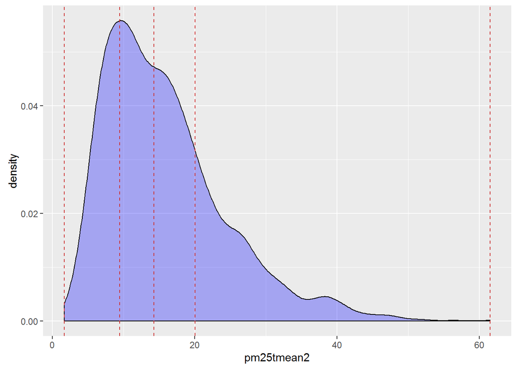

```r
ggplot(chicago_since2000, aes(x=pm25tmean2)) + geom_density(fill = "blue", alpha = 0.3) + geom_vline(xintercept=quantile(chicago_since2000$pm25tmean2,na.rm = TRUE), linetype = 2, color = 'brown3')
```

**To understand those rows with high PM2.5 values, I extracted the rows with PM2.5 values above 75% quantile.**The extraction was done by adding a label column.

As discussed in the cleaning missing data part, I omitted rows containing missing values of PM2.5 for the subset of records from 2000 to 2005.

The PM2.5 of Chicago reached its highest 10 values in below 10 days from 2000 to 2005.

```r
arrange(chicago_since2000, desc(pm25tmean2))%>%
  head(10)
```

```
## # A tibble: 10 × 9
##     city  tmpd  dptp       date pm25tmean2 pm10tmean2  o3tmean2 no2tmean2
##    <chr> <dbl> <dbl>     <date>      <dbl>      <dbl>     <dbl>     <dbl>
## 1   chic    36  32.1 2005-02-04   61.50000       57.5  4.812500  41.52778
## 2   chic    80  61.8 2005-09-11   56.50000       65.0 51.739583  18.87500
## 3   chic    26  20.0 2005-02-02   52.00000       50.5  6.241477  46.36111
## 4   chic    82  64.6 2005-06-27   51.53750       79.0 55.235857  28.54937
## 5   chic    18  14.6 2001-01-22   49.47143       68.0  3.125000  43.67708
## 6   chic    29  23.5 2004-02-18   48.15714       61.0  8.162138  43.70833
## 7   chic    NA  22.9 2003-03-01   47.73750       47.5  9.416667  37.44444
## 8   chic    26  24.7 2001-02-07   47.50000       34.0  4.729167  38.59876
## 9   chic    30  25.0 2005-02-03   47.45000       53.6  7.269022  48.59722
## 10  chic    36  25.1 2001-03-03   47.40000       49.5  6.187500  48.71875
## # ... with 1 more variables: PM2.5_0.75quantile <fctr>
```

## 4. Analysing the relationship between high PM2.5 and other pollutants

I further explored the subset of days with PM2.5 level above its 75% quantile to see if other pollutants were linked to high PM2.5.

> PM10 Level

**From the box plot and scatter plot with fitted smooth line below, it is clear that when PM2.5 is higher, the PM10 is generally also higher in Chicago.**

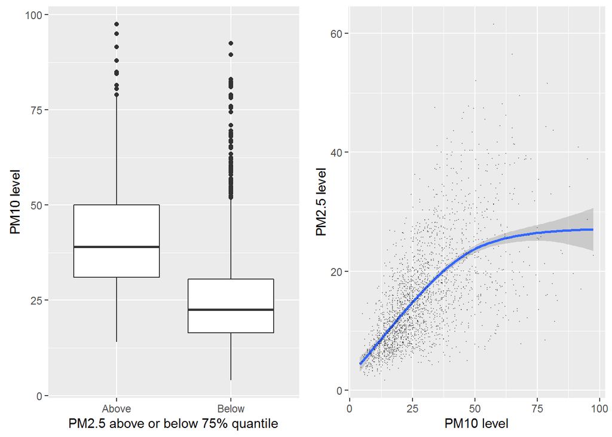

```r
g13 <- ggplot(chicago_since2000, aes(PM2.5_0.75quantile, y = pm10tmean2)) + geom_boxplot() + labs(x = 'PM2.5 above or below 75% quantile',y = 'PM10 level')

g14<- ggplot(chicago_since2000, aes(x=pm10tmean2,y=pm25tmean2)) + geom_smooth()+geom_point(alpha = 0.3, size = 0.1) + labs(x = "PM10 level", y = "PM2.5 level")

grid.arrange(g13,g14, ncol = 2)
```

> Ozone Level

**The relationship between Ozone(O3) and PM2.5 showed on the scatter plot follows a U shape.There are much less points on the right side of the U shape. In most occassions higher level of PM2.5 is related with less Ozone.**

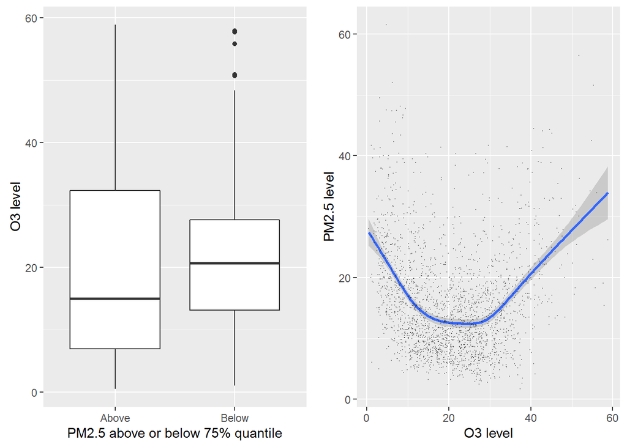

```r
g15 <- ggplot(chicago_since2000, aes(x = PM2.5_0.75quantile, y = o3tmean2)) + geom_boxplot() + labs(x = 'PM2.5 above or below 75% quantile',y = 'O3 level')

g16<- ggplot(chicago_since2000, aes(x=o3tmean2, y=pm25tmean2)) + geom_smooth()+geom_point(alpha = 0.3, size = 0.1) + labs(x = "O3 level", y = "PM2.5 level")

grid.arrange(g15,g16, ncol = 2)
```

> Nitrogen Dioxide (No2) Level

**The level of PM2.5 is also possitive related with the level of NO2 in Chicago.**

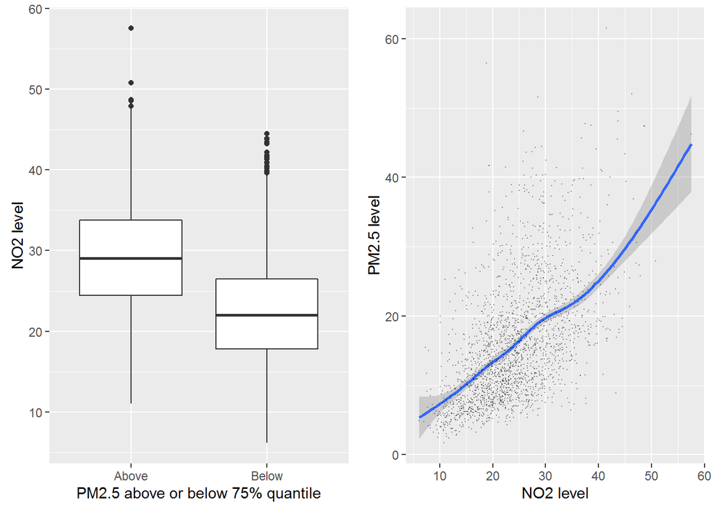

```r
g17 <- ggplot(chicago_since2000, aes(y=no2tmean2, x = PM2.5_0.75quantile)) + geom_boxplot() + labs(x = 'PM2.5 above or below 75% quantile',y = 'NO2 level')

g18<- ggplot(chicago_since2000, aes(x=no2tmean2, y=pm25tmean2)) + geom_smooth()+geom_point(alpha = 0.3, size = 0.1) + labs(x = "NO2 level", y = "PM2.5 level")

grid.arrange(g17,g18, ncol = 2)
```

> TMPD

**There is little relationship between tmpd and PM2.5.**

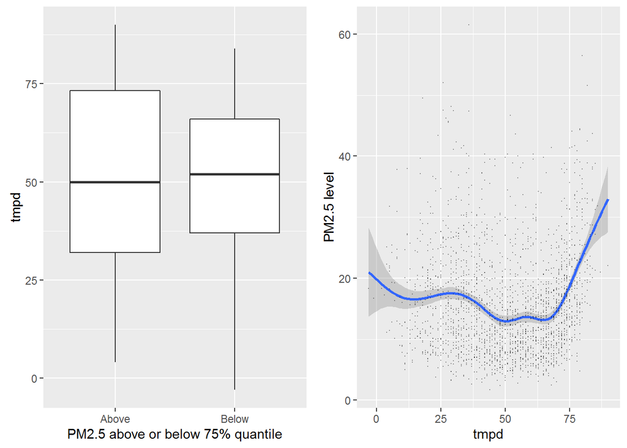

```r
g19 <- ggplot(chicago_since2000, aes(y=tmpd, x = PM2.5_0.75quantile)) + geom_boxplot() + labs(x = 'PM2.5 above or below 75% quantile',y = 'tmpd')

g20 <- ggplot(chicago_since2000, aes(x=tmpd, y=pm25tmean2)) + geom_smooth()+geom_point(alpha = 0.3, size = 0.1) + labs(x = "tmpd", y = "PM2.5 level")

grid.arrange(g19,g20, ncol = 2)
```

> DPTP

**Similar to tmpd, there is also little relationship between DPTP and PM2.5**

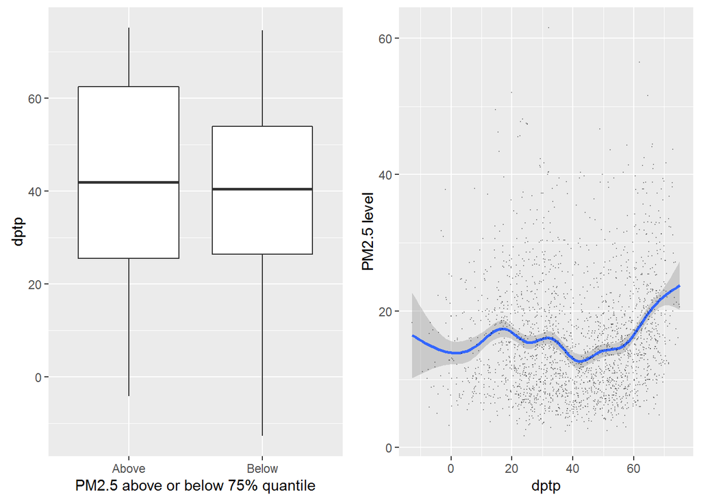

```r
g21 <- ggplot(chicago_since2000, aes(y=dptp, x = PM2.5_0.75quantile)) + geom_boxplot() + labs(x = 'PM2.5 above or below 75% quantile',y = 'dptp')

g22 <- ggplot(chicago_since2000, aes(x=dptp, y=pm25tmean2)) + geom_smooth()+geom_point(alpha = 0.3, size = 0.1) + labs(x = "dptp", y = "PM2.5 level")

grid.arrange(g21,g22, ncol = 2)
```

## 5. Normalization

**Create one column with z-score normalized PM2.5 values**

```r
pm25mean <- mean(chicago_since2000$pm25tmean2)
pm25std <- sd(chicago_since2000$pm25tmean2)
chicago_since2000$pm25Norm <- (chicago_since2000$pm25tmean2 - pm25mean)/pm25std
```

**Create another column with min-max normalized PM10 values**

```r
pm10min <- min(chicago_since2000$pm10tmean2)
pm10max <- max(chicago_since2000$pm10tmean2)
chicago_since2000$pm10Norm <- (chicago_since2000$pm10tmean2 - pm10min)/(pm10max - pm10min)
```

## 6. Adding Year column

```r
year = as.POSIXlt(chicago$date)$year + 1900
chicago$year = year

year_since2000 = as.POSIXlt(chicago_since2000$date)$year + 1900
chicago_since2000$year = year_since2000
```

## 7. Key summary statistics of the pollutants by year

### Polutants except PM2.5

As discussed in missing data cleaning part, by year analysis of PM2.5 for years before 2000 will probably be biased due to large proportion of missing data. I will use subset of data since year 2000 for PM2.5 later.

> By year mean of pollutants except PM2.5

```r
group_by(chicago, year) %>%
  summarise(AvgPM10 = mean(pm10tmean2,na.rm = TRUE),
            AvgO3 = mean(o3tmean2, na.rm = TRUE),
            AvgNO2 = mean(no2tmean2, na.rm = TRUE),
            Avgtmpd = mean(tmpd, na.rm = TRUE),
            Avgdptp = mean(dptp, na.rm = TRUE))
```

```
## # A tibble: 19 × 6
##     year  AvgPM10    AvgO3   AvgNO2  Avgtmpd  Avgdptp
##    <dbl>    <dbl>    <dbl>    <dbl>    <dbl>    <dbl>
## 1   1987 40.30734 20.49656 25.29139 52.12603 41.73527
## 2   1988 42.17453 22.24508 25.34194 49.93579 37.31626
## 3   1989 40.28531 20.81377 27.36487 48.36712 38.19623
## 4   1990 35.49528 19.72982 23.05653 51.67260 42.09932
## 5   1991 36.87695 20.00840 21.91641 51.40274 41.13390
## 6   1992 38.81634 16.05586 25.85826 48.81148 40.11339
## 7   1993 36.46598 15.80195 26.13133 48.71918 40.85993
## 8   1994 39.65146 17.32355 29.10232 50.08219 39.37598
## 9   1995 35.61745 18.13865 27.94671 50.20959 39.50103
## 10  1996 31.66569 16.74696 26.98163 47.39481 39.92452
## 11  1997 30.79363 18.60359 25.75996 48.70959 39.92764
## 12  1998 30.93457 19.27065 24.73751 53.78356 44.26521
## 13  1999 31.30980 20.46593 24.93339 51.46301 40.98630
## 14  2000 30.48314 18.53101 24.07310 50.04098 40.25164
## 15  2001 32.43049 19.35421 25.38962 51.04384 41.31233
## 16  2002 29.35375 20.98978 23.66768 51.16986 41.45000
## 17  2003 27.50511 20.97764 25.24405 49.30495 38.34110
## 18  2004 27.86416 20.53633 23.44489 50.12568 39.98877
## 19  2005 28.64699 23.19340 23.16542 51.52603 39.72658
```

**Above mean summary shows the average PM10 level in Chicago decreased from 1987 to 2005.While other pollutants fluctuated around a relatively fixed level.**

> By year standard deviation of pollutants except PM2.5

```r
group_by(chicago, year) %>%
  summarise(stdPM10 = sd(pm10tmean2,na.rm = TRUE),
            stdO3 = sd(o3tmean2, na.rm = TRUE),
            stdNO2 = sd(no2tmean2, na.rm = TRUE),
            stdtmpd = sd(tmpd, na.rm = TRUE),
            stddptp = sd(dptp, na.rm = TRUE))
```

```
## # A tibble: 19 × 6
##     year  stdPM10     stdO3   stdNO2  stdtmpd  stddptp
##    <dbl>    <dbl>     <dbl>    <dbl>    <dbl>    <dbl>
## 1   1987 17.20362 12.349994 8.875460 18.37478 18.16524
## 2   1988 21.67941 13.630039 8.361641 21.67978 18.76900
## 3   1989 18.06566 11.472368 8.878810 20.54242 19.77437
## 4   1990 16.90671 10.653854 7.750973 17.47688 17.81814
## 5   1991 18.03135 11.852847 7.490050 20.33296 18.50110
## 6   1992 19.75854  9.917459 7.317283 16.60611 15.91384
## 7   1993 17.67431  9.498124 7.173524 18.85325 18.66645
## 8   1994 21.24038 10.278515 8.534887 20.33440 18.82634
## 9   1995 17.72354 12.338676 8.530292 21.14193 19.75142
## 10  1996 14.94054 10.692916 7.422589 20.00142 20.15895
## 11  1997 14.86207 10.846079 7.817029 19.04745 17.73892
## 12  1998 14.04589 11.668973 7.237748 17.62100 16.79682
## 13  1999 15.87607 11.719367 7.387345 19.14683 18.05392
## 14  2000 15.30859 10.232556 7.938701 19.91244 18.76278
## 15  2001 16.69597 11.221794 7.134908 18.72908 17.92967
## 16  2002 15.99707 11.536947 7.111896 18.99692 18.46703
## 17  2003 14.33646 10.916542 8.009054 19.20465 18.75984
## 18  2004 14.06255  9.315787 7.321528 18.80369 18.51162
## 19  2005 14.07087 12.323091 7.609107 20.60520 18.67498
```

**Above standard deviation summary shows the flunctuation of daily PM10 records followed a decreasing trend from 1987 to 2005. While the daily flunctuation of other pollutants remained at a relatively stable level.**

> By year minimum level of pollutants except PM2.5

```r
group_by(chicago, year) %>%
  summarise(minPM10 = min(pm10tmean2,na.rm = TRUE),
            minO3 = min(o3tmean2, na.rm = TRUE),
            minNO2 = min(no2tmean2, na.rm = TRUE),
            mintmpd = min(tmpd, na.rm = TRUE),
            mindptp = min(dptp, na.rm = TRUE))
```

```
## # A tibble: 19 × 6
##     year minPM10     minO3    minNO2 mintmpd mindptp
##    <dbl>   <dbl>     <dbl>     <dbl>   <dbl>   <dbl>
## 1   1987  10.000 2.1250000  7.866667     2.0 -12.250
## 2   1988   6.000 2.3750000  7.733333    -6.5 -15.875
## 3   1989   9.375 2.0000000  9.580729    -6.5 -23.000
## 4   1990   4.000 2.1250000  6.726172     3.5  -7.875
## 5   1991   2.000 2.0000000  6.385417     6.5  -6.250
## 6   1992   2.000 2.0000000  9.962500     5.5  -9.625
## 7   1993   3.000 0.4270833 10.263768     5.0  -5.750
## 8   1994   3.000 0.1527778 10.944444   -16.0 -25.625
## 9   1995   7.500 0.5169082  8.925000     0.5 -13.250
## 10  1996   8.000 1.1666667 10.458333   -12.0 -21.000
## 11  1997   6.000 0.9565217  7.729167    -3.0 -10.375
## 12  1998   4.500 0.5555556  8.800000     7.0  -6.000
## 13  1999   4.500 0.8541667  7.641667    -2.0  -6.900
## 14  2000   4.500 1.0416667  6.158333    -1.0  -7.100
## 15  2001   5.000 0.5000000  8.650000     5.0  -1.700
## 16  2002   4.000 2.0964674  7.802083     6.0  -0.600
## 17  2003   6.500 1.0978261  7.697917     4.0  -9.300
## 18  2004   5.000 2.1965580  7.552083    -3.0 -12.700
## 19  2005   5.000 1.7708333  8.833333     5.0  -7.800
```

> By year maximum value of pollutants except PM2.5

```r
group_by(chicago, year) %>%
  summarise(maxPM10 = max(pm10tmean2,na.rm = TRUE),
            maxO3 = max(o3tmean2, na.rm = TRUE),
            maxNO2 = max(no2tmean2, na.rm = TRUE),
            maxtmpd = max(tmpd, na.rm = TRUE),
            maxdptp = max(dptp, na.rm = TRUE))
```

```
## # A tibble: 19 × 6
##     year maxPM10    maxO3   maxNO2 maxtmpd maxdptp
##    <dbl>   <dbl>    <dbl>    <dbl>   <dbl>   <dbl>
## 1   1987 117.000 62.96966 57.52542    87.0  75.875
## 2   1988 148.000 61.67708 62.47998    89.5  76.625
## 3   1989 115.000 59.72727 59.51562    86.5  77.000
## 4   1990 104.625 52.22917 46.19444    86.5  75.875
## 5   1991 131.000 63.10417 55.48958    88.0  71.750
## 6   1992 141.000 50.82870 49.77714    80.0  77.250
## 7   1993 107.000 44.30093 48.90139    84.0  78.125
## 8   1994 131.000 52.17844 53.89485    86.0  74.000
## 9   1995  92.500 66.58750 53.13333    92.0  76.375
## 10  1996 128.000 58.39583 52.68850    83.0  78.250
## 11  1997 113.500 56.54167 53.01042    85.5  75.750
## 12  1998  91.000 50.66250 47.81558    85.0  72.900
## 13  1999  91.000 57.48864 49.54924    90.0  77.100
## 14  2000  85.000 55.76103 50.81123    82.0  70.700
## 15  2001  97.500 51.81984 48.71875    85.0  75.100
## 16  2002  95.000 54.88043 47.76042    87.0  74.900
## 17  2003  75.000 56.16608 57.56439    84.0  71.600
## 18  2004  82.000 44.48240 44.97817    83.0  72.800
## 19  2005  79.000 58.84126 48.59722    90.0  71.400
```

### By Year summary of PM2.5

```r
group_by(chicago_since2000, year) %>%
  summarise(meanPM2.5 = mean(pm25tmean2,na.rm = TRUE),
            stdPM2.5 = sd(pm25tmean2, na.rm = TRUE),
            maxPM2.5 = max(pm25tmean2, na.rm = TRUE),
            minPM2.5 = min(pm25tmean2, na.rm = TRUE))
```

```
## # A tibble: 6 × 5
##    year meanPM2.5 stdPM2.5 maxPM2.5 minPM2.5
##   <dbl>     <dbl>    <dbl>    <dbl>    <dbl>
## 1  2000  16.93806 8.373305 46.70000   2.8000
## 2  2001  16.92632 9.223039 49.47143   3.2000
## 3  2002  15.27335 7.994100 44.04286   2.9125
## 4  2003  15.23183 8.260719 47.73750   2.5000
## 5  2004  14.62864 7.620417 48.15714   2.6000
## 6  2005  16.18556 9.679448 61.50000   1.7000
```

**For PM2.5, although it yearly average level remained relatively stable from 2000 to 2005, the maximum level climbed from 47 in 2000 to 61 in 2005 which threated Chicago environment.**

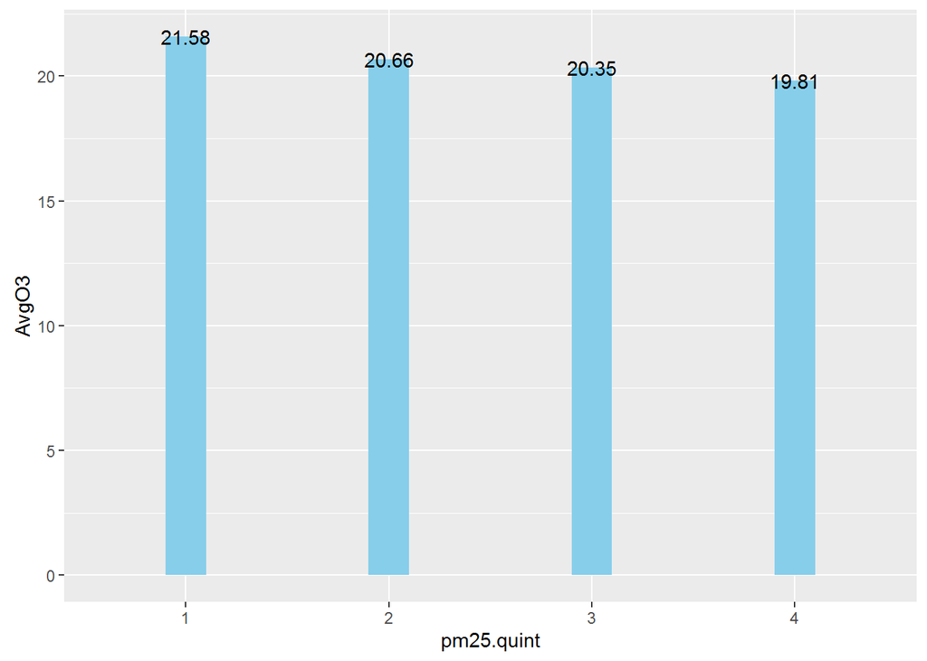

```r
o3_pm25 = subset(chicago_since2000, !is.na(pm25.quint)) %>%
  group_by(pm25.quint) %>%
  summarise(AvgO3 = mean(o3tmean2, na.rm = TRUE))

ggplot(o3_pm25, aes(x = pm25.quint, y = AvgO3)) + geom_bar(stat="identity", width = 0.2, fill = "skyblue") + geom_text(aes(label= round(AvgO3,2)))
```

**Above chart shows the average level of Ozone is higher for PM2.5 within lower quantiles. Thus reducing the level of PM2.5 can help protecting Ozone.**